# re_stepwise

David Fäh 23-106-396

2025-04-07

## Introduction

```r
# load libraries
library(tidyverse)
library(ggplot2)
library(cowplot)


# load data
url_01 <- "https://raw.githubusercontent.com/geco-bern/agds_book/refs/heads/main/book/data/df_for_stepwise_regression.csv"

half_hourly_fluxes <- read.table(
  url_01,
  header = TRUE,
  sep = ","
)

# select numeric variables only and drop NA
fluxes_numeric <- half_hourly_fluxes |>
  select(-starts_with("TIMESTAMP"), -starts_with("siteid")) |>
  drop_na()
```

## Bivariate model

```r
# create data frame to store results
lm_results <- data.frame(
  predictor = character(),
  R2 = numeric())


# create vector to store possible predictors
predictors <- setdiff(names(fluxes_numeric), "GPP_NT_VUT_REF")


# fit linear regression models with different predictors
for (predictor in predictors){

  # define the model
  lm_formula <- as.formula(paste("GPP_NT_VUT_REF ~ ", predictor))
  linear_model <- lm(lm_formula, data = fluxes_numeric)

  # calculate coefficient of determination R²
  r2 <- summary(linear_model)$r.squared

  # store results
  lm_results <- bind_rows(
    lm_results,
    data.frame(predictor = predictor, R2 = r2))
}


# select the predictor with highest R²
best_single_predictor <- lm_results$predictor[which.max(lm_results$R2)]


# define best bivariate model
best_bivariate_model <- lm(
  GPP_NT_VUT_REF ~ fluxes_numeric[[best_single_predictor]],
  data = fluxes_numeric)


# calculate AIC for best bivariate model
bivariate_model_aic <- AIC(best_bivariate_model)
```

**Visualization and discussing results**

Comparing R² values of the different models with a bar plot:

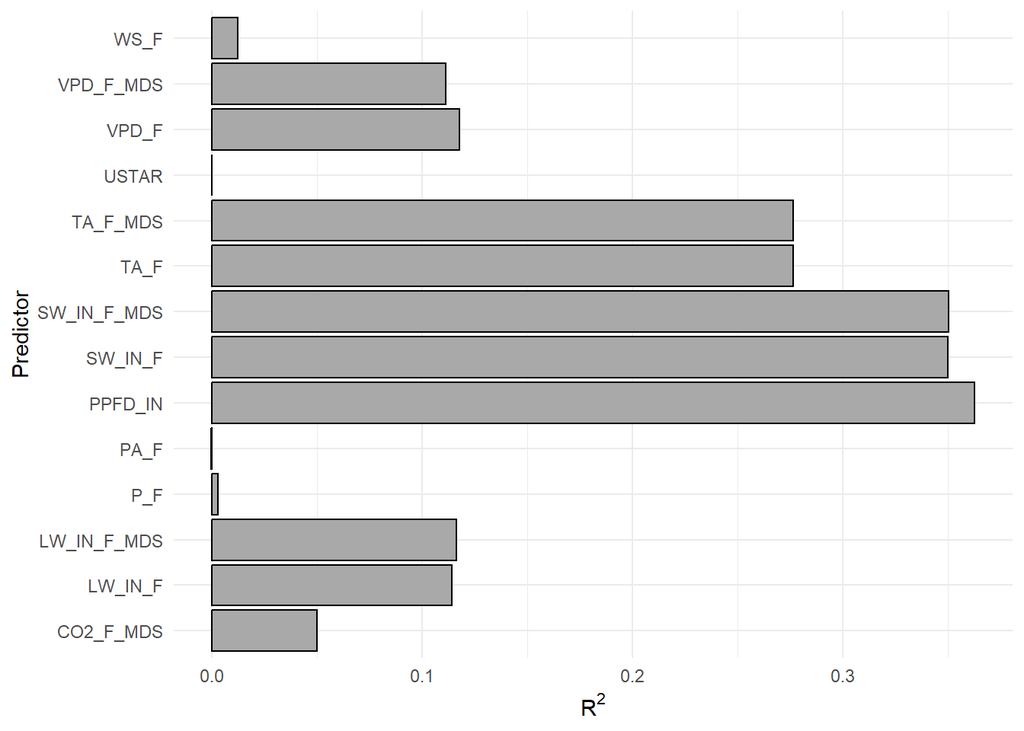

```r
# compare R² values of linear models visually
barplot_lm_results <- ggplot(
  lm_results,
  aes(x = predictor, y = R2)) +
  geom_bar(
    stat = "identity",
    fill = "darkgrey",
    color = "black") +
  labs(
    x = "Predictor",
    y = expression(R^2)) +
  coord_flip() +
  theme_minimal()

barplot_lm_results
```

This barplot shows that for a bivariate linear regression model, PPFD_IN explains the most variance in GPP among all tested predictors.

Because it has the highest R² value:

```r
# print R² of the best predictor
knitr::kable(lm_results[which.max(lm_results$R2), ],
             row.names = FALSE)
```

| predictor | R2 |
| --- | --- |
| PPFD_IN | 0.3627837 |

```r
# print aic of best bivariate model
cat("The AIC of the linear model that uses PPFD_IN as predictor is:", bivariate_model_aic)
```

```
## The AIC of the linear model that uses PPFD_IN as predictor is: 45682.99
```

**PPFD_IN** stands for **Photosynthetic Photon Flux Density incoming**.

- It measures the amount of light available for plants to photosynthesize (400-700nm), that reaches a surface.
- It is measured in: μmol photons * m⁻² * s⁻¹
- I think it makes sense that PPFD_IN can explain parts of GPP because plants require light to photosynthesize. When there is more light available, this might enhance photosynthesis. Leading to increased productivity and therefore to a higher GPP.

## Stepwise forward regression

```r
# define vector containing potential predictors for GPP
predictors <- setdiff(names(fluxes_numeric), "GPP_NT_VUT_REF")


# define vector to store best predictors
best_model_predictors <- c()


# define data frame to store results
stepwise_results <- data.frame(
  predictor = character(),
  R2 = numeric())


# make sure the loop runs at least once
new_model_aic <- -Inf
best_model_aic <- Inf


# store R² and AIC results over iterations
r2_values <- c()
aic_values <- c()



# loop runs until new model's AIC is higher than previous model's AIC
while(TRUE){

  # make sure data does not accumulate in storage data frame (clear for every iteraton)
  stepwise_results <- data.frame(
    predictor = character(),
    R2 = numeric())


  for (predictor in predictors){

    # define formula for new model with additional predictor
    formula <- as.formula(
      paste("GPP_NT_VUT_REF ~ ", paste(c(best_model_predictors, predictor), collapse = "+")))

    # fit new model
    new_model <- lm(formula, data = fluxes_numeric)

    # calculate R² for new model
    r2 <- summary(new_model)$r.squared

    # store results
    stepwise_results <- bind_rows(
      stepwise_results,
      data.frame(predictor = predictor, R2 = r2))
  }


  # select best additional predictor based om highest R²
  best_new_predictor <- stepwise_results$predictor[which.max(stepwise_results$R2)]

  # define new model with best additional predictor
  formula <- as.formula(
    paste("GPP_NT_VUT_REF ~ ", paste(c(best_model_predictors, best_new_predictor), collapse = "+")))
  new_model <- lm(formula, data = fluxes_numeric)

  # calculate AIC for new model
  new_model_aic <- AIC(new_model)


  # check if new model is better than the previous one
  if (new_model_aic < best_model_aic){

    # define best model and metrics
    best_model <- new_model
    best_model_aic <- new_model_aic
    best_model_r2 <- summary(new_model)$r.squared

    # add best new predictor to the vector of model predictors
    best_model_predictors <- c(best_model_predictors, best_new_predictor)

    # remove added predictor from the list of potential predictors
    predictors <- setdiff(predictors, best_new_predictor)

    # store R² and AIC values for current model
    r2_values <- c(r2_values, best_model_r2)
    aic_values <- c(aic_values, best_model_aic)
  }

  # if the old model is better, end the algorithm
  else {

    break

  }
}



# print the result
cat(
  paste("The best fitting model is:", paste(format(formula(best_model)), collapse = "")))
```

```
## The best fitting model is: GPP_NT_VUT_REF ~ PPFD_IN + LW_IN_F + VPD_F + TA_F_MDS + WS_F +     USTAR + SW_IN_F + P_F + CO2_F_MDS + PA_F
```

**Plot R² and AIC for every step to check how these metrics developed across** **the stepwise forward regression:**

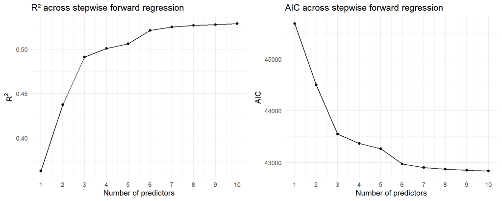

```r
# plot R² for every step
plot_r2_stepwise <- ggplot(
  data = NULL,
  aes(x = seq_along(r2_values), y = r2_values)) +
  geom_point() +
  geom_line() +
  labs(x = "Number of predictors",
       y = expression(R^2),
       title = "R² across stepwise forward regression") +
  scale_x_continuous(breaks = seq(1, length(r2_values), by = 1)) +
  theme_minimal()


# plot AIC for every step
plot_aic_stepwise <- ggplot(
  data = NULL,
  aes(x = seq_along(r2_values), y = aic_values)) +
  geom_point() +
  geom_line() +
  labs(x = "Number of predictors",
       y = "AIC",
       title = "AIC across stepwise forward regression") +
  scale_x_continuous(breaks = seq(1, length(r2_values), by = 1)) +
  theme_minimal()


# combine plots
plot_grid(plot_r2_stepwise, plot_aic_stepwise, ncol = 2)
```

## Interpretation

**Developement of R² and AIC:**

- R²: As expected, R² increased with each additional predictor. The greatest improvements occured within the first 6 predictors. After that, there were only minor improvements in performance.
- AIC: The AIC decreased with each additional predictor. At predictor number 11, the curve would have started to rise again, so the loop stopped and selected the optimal model according to the AIC. At this point, the penalty term of the AIC began to take effect. Although AIC penalizes excessive model complexity, the final model included 10 predictors. However, it’s important to note that after predictor 6, the improvements in AIC were relatively small compared to the added complexity. Therefore, I argue that although the model with 10 predictors achieves the lowest AIC, a simpler model could be preferable—one that significantly reduces complexity without a substantial loss in performance.

**The predictors (added in this order) of the best model are:**

- 1. **PPFD_IN** (Photosynthetic photon flux density, incoming): Discussed above.
- 2. **LW_IN_F** (Longwave radiation, incoming, consolidated from LW_IN_F_MDS and LW_IN_ERA): Influences surface and canopy temperatures. Higher incoming longwave radiation can enhance photosynthesis by warming the plant. Plants are more productive at higher temperatures.
- 3. **VPD_F** (Vapor Pressure Deficit consolidated from VPD_F_MDS and VPD_ERA): A measure of atmospheric dryness. High VPD limits photosynthesis because plants close their stomata to conserve water. This limits the CO2 uptake, and reduced productivity.
- 4. **TA_F_MDS** (Air temperature, gapfilled using MDS method): Temperature affects the rate of photosynthesis of plants. Higher temperatures enhance photosynthesis and increased productivity.
- 5. **WS_F** (Wind speed, consolidated from WS and WS_ERA): High wind speeds enhance atmospheric mixing. This might improve CO2 availability and diffusion into leaves. Thus enhancing photosynthesis and productivity.
- 6. **USTAR** (Friction velocity): Similar to wind speed. Measurement of turbulence near the surface. This might complement wind speed.
- 7. **SW_IN_F** (Shortwave radiation, incoming consolidated from SW_IN_F_MDS and SW_IN_ERA, negative values set to zero): Represents solar energy input. Similar to PPFD_IN, might include some complementary information about energy that is available to plants.
- 8. **P_F** (Precipitation consolidated from P and P_ERA): Precipitation influences soil moisture and water availability, which is required for photosynthesis.
- 9. **CO2_F_MDS** (CO2 mole fraction, gapfilled with MDS): CO2 concentration influences carbon uptake of plants. Elevated CO2 levels might enhance photosynthesis and production.
- 10. **PA_F** (Atmospheric pressure consolidated from PA and PA_ERA): Atmospheric pressure might impact the rate at which plants take up CO2, influencing photosynthesis.

**The included predictors can be categorized into different categories:**

- **Light and energy related**: Availability of light directly drives photosynthesis. They have a very strong impact.
- **Temperature**: Affects enzymatic reactions in photosynthesis. Warmer temperatures enhance productivity.
- **Water availability**: Water, both in the soil and in the atmosphere is required for photosynthesis.
- **CO2**: Is needed for the plant to fix carbon during photosynthesis. Higher levels enhance productivity.
- **Wind and turbulence**: Influence the mixing of CO2 and water vapor which are important for photosynthesis.

**Predictors that were not included in the final model are:**

- **TA_F**: Air temperature, consolidated from TA_F_MDS and TA_ERA
- **SW_IN_F_MDS**: Shortwave radiation, incoming, gapfilled using MDS (negative values set to zero, e.g., negative values from instrumentation noise)
- **LW_IN_F_MDS**: Longwave radiation, incoming, gapfilled using MDS
- **LW_IN_F_MDS**: Longwave radiation, incoming, gapfilled using MDS
- **VPD_F_MDS**: Vapor Pressure Deficit, gapfilled using MDS

These predictors might have been excluded due to collinearity. Their information was already covered by similar variables in the model. In most cases, the gapfilled versions were left out, which can have two reasons:

- The model favored similar variables that were not gapfilled because of more complete and exact data that explained the variance.
- Since stepwise forward regression was used to find the best fitting model, the order in which the variables were evaluated have an influence. So, if a similar variable has already been inlcuded, the new one was skipped because it was mostly redundant and did not offer enough additional information to improve the model further.